# 1.1W--Lesson-1.1--Virtual-Machine-Docker-Setup

============================== Virtual Machine & Docker Setup ==============================

A typical Windows 10 installation does not include several of the tools needed to run the GridAPPS-D Platform Several software packages need to be installed prior to installing GridAPPS-D in the next step

Installation Steps:

- 1. Verify System Requirements
- 2. Verify OS Build
- 3. Install Windows Subsystem for Linux
  - 3.1. Enable WSL
  - 3.2. Upgrade to WSL2
  - 3.3. Install Linux Ubuntu OS
  - 3.4. Set up Ubuntu in WSL
- 4. Install Docker for Windows

# 1. Verify System Requirements

- **OS:**
  - Windows 10, Version 2004 or higher, with Build 19041 or higher
- **RAM:**
  - 8GB (*absolute minimum* for 13 and 123 node models, *may encounter memory overload during installation* );
  - 16GB (preferred for small models, minimum for 8500/9500 node models);
  - 32GB (recommended for application development)
- **Disk Space:**
  - 15GB required for installation

**Note:** The download size is quite large, so it is recommended to use a fiber or ethernet interent connection, rathered than a metered hotspot to avoid excessive data usage charges.

# 2. Verify OS Build

To check your OS build, type `winver` in the Cortana seach bar:

[figure not shown]

Check to see if your OS is

- For x64 systems: **Version 1903 or higher, with Build 18362 or higher.**
- For ARM64 systems: **Version 2004 or higher, with Build 19041 or higher.**

[figure not shown]

If not, run **Windows Update** to get the latest verion of Windows 10 available for your machine. It may take some time for the new OS to download. Multiple restarts are typical while upgrading the windows version.

# 3. Install Windows Subsystem for Linux

GridAPPS-D and the associated docker containers will run using the Windows Subsystem for Linux (WSL), which is a new feature to Windows 10 that enables linux code to run natively in Windows without a separate virtual machine. The steps in this section are also available on the [Microsoft website](https://docs.microsoft.com/en-us/windows/wsl/install-win10)

## 3.1. Enable WSL

Open Windows PowerShell as an administrator:

[figure not shown]

Enable WSL by entering

`dism.exe /online /enable-feature /featurename:Microsoft-Windows-Subsystem-Linux /all /norestart`

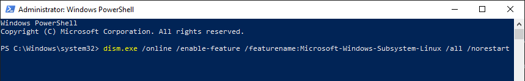

Then, without restarting, enable the virtual machine platform by entering

`dism.exe /online /enable-feature /featurename:VirtualMachinePlatform /all /norestart`

[figure not shown]

When completed, restart your machine. It may take a few minutes for the new settings to be applied while restarting.

## 3.2. Upgrade to WSL2

Download the latest WSL2 package .msi installer from the [Microsoft repository](https://wslstorestorage.blob.core.windows.net/wslblob/wsl_update_x64.msi)

Run the update package to install WSL2 using the wizard:

[figure not shown]

Open Windows PowerShell again and update the settings to use WSL2 by entering

`wsl --set-default-version 2`

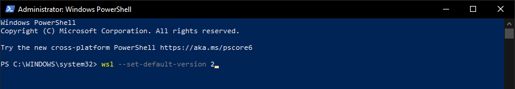

## 3.3. Install Linux Ubuntu OS

Open the Microsoft Store app, and search for `Ubuntu` and install the desired version (available versions are 16.04, 18.04, and 20.04)

[figure not shown]

When it has finished downloading, click `Launch`.

[figure not shown]

## 3.4. Set up Ubuntu in WSL

Wait for the Ubuntu OS to install.

[figure not shown]

Select a username and password. These do not need to be the same as your Windows or Microsoft Account login.

[figure not shown]

# 4. Install Docker for Windows

Download and run **Docker Desktop for Windows** from [Docker Hub](https://desktop.docker.com/win/stable/Docker%20Desktop%20Installer.exe)

Be sure to select "**Install required components for WSL2**"

[figure not shown]

After restarting your machine, Docker should start automatically, and you will see a notification stating "**Linux WSL2 containers are starting**"

[figure not shown]